Ir al contenido

Ficha actualizada el 12 nov 2026

Ficha del establecimiento · RBD 9446

# Escuela De Párvulos Rayito De Luz

Pedro Aguirre CerdaEscuela de PárvulosCon Programa de Integración Escolar

Stephanie Sofia Aranda Figueroa (s)

Dirección del establecimiento

🎒Matrícula

82

−28 respecto de 2025

📅Asistencia promedio

87,5 %

4,8 puntos sobre el promedio del SLEP

📇Estudiantes prioritarios

61,1 %

Concentración declarada (marzo)

🧭NT1 en Consolidando o Profundizando (DIA)

10,5 %

evaluación de inicio 2026 · 51 niñas y niños

¿Primera vez leyendo una ficha?Empieza por la ficha en cifras[Guía para leer los datos (se abre en otra pestaña)](https://datos.slepsantarosa.workers.dev/guia.html)

## La ficha en cifras

Cada cifra enlaza a su sección, donde está explicada y comparada con el SLEP.

📇Estudiantes prioritarios61,1 %Concentración declarada (marzo)Ver sección: Estudiantes prioritarios →

🎒Matrícula82−28 respecto de 2025Ver sección: Matrícula →

📅Asistencia promedio87,5 %4,8 puntos sobre el promedio del SLEPVer sección: Asistencia promedio →

🤝Estudiantes en el PIE1012,2 % de la matrículaVer sección: Estudiantes en el PIE →

🚶Retiros en 202656,1 % de la matrículaVer sección: Retiros en 2026 →

🧭NT1 en Consolidando o Profundizando (DIA)10,5 %evaluación de inicio 2026 · 51 niñas y niñosVer sección: NT1 en Consolidando o Profundizando (DIA) →

👥Funcionarios2811 docentes y 17 asistentes de la educaciónVer sección: Funcionarios →

📈Docentes en tramo avanzado o superior45 %5 de 11 docentesVer sección: Docentes en tramo avanzado o superior →

📜Acciones del plan de mejoramiento15Plan 2025, en 4 dimensionesVer sección: Acciones del plan de mejoramiento →

⭐SNED 2026-2027No seleccionadoÍndice de 63,9 sobre 100Ver sección: SNED 2026-2027 →

🔗Convenios de uso de espacios2Organizaciones que usan sus espaciosVer sección: Convenios de uso de espacios →

🚨Hechos delictuales registrados1Último en 24 jun 2026Ver sección: Hechos delictuales registrados →

🗺️Niños y jóvenes en el barrio4.602De 0 a 17 años, a 800 m a la redondaVer sección: Niños y jóvenes en el barrio →

Capítulo

¿Qué establecimiento es y qué ofrece?

## 🏫El establecimiento

- 📇Identificación y contacto
- 🎭Vida escolar y participación

El establecimiento · Identificación y contactoDatos al 16 oct 2026

### 📇Identificación y contacto

¿Qué establecimiento es y cómo contactarlo?

Escuela de Párvulos en funcionamiento en Pedro Aguirre Cerda, imparte educación parvularia y atiende a 82 estudiantes.

[figure not shown]

📷Fotografías del establecimiento

Concentración de estudiantes prioritarios

61,1 %

Estudiantes cuya situación socioeconómica puede afectar su rendimiento, según el Ministerio de Educación.

Cursos en funcionamiento

6

En educación parvularia

Programas y convenios

1

Programa de Integración Escolar

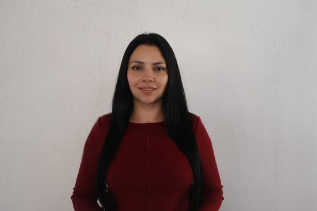

👤Dirección del establecimiento

Stephanie Sofia Aranda Figueroa (s)

✉️escuelarayitodeluz@slepsantarosa.cl

📱Celular: +56 9 7103 6646

☎️Teléfono del establecimiento: 23965836

🤝Asesoría técnica del SLEP: Rubén Cortez Gallardo · ruben.cortez@slepsantarosa.gob.cl

📍Dónde queda

Mariquina 3244 3244, Pedro Aguirre Cerda.

[interactive chart not shown]

Fuente: Coordenadas del directorio consolidado · [Abrir en Google Maps](https://www.google.com/maps/search/?api=1&query=-33.48273,-70.67844)

#### Identificación

**RBD**

9446-3

**Tipo de establecimiento**

Escuela de Párvulos

**Dependencia**

Servicio Local de Educación Pública Santa Rosa

**Estado**

Funcionando

**Comuna**

Pedro Aguirre Cerda

#### Cómo contactarlo

**Dirección**

Mariquina 3244 3244

**Teléfono**

23965836

**Correo**

escuelarayitodeluz@slepsantarosa.cl

#### Equipo y apoyo técnico

**Dirección**

Stephanie Sofia Aranda Figueroa (s)

**Unidad Técnico Pedagógica**

utp.escuelarayitodeluz@slepsantarosa.cl

**Inspectoría**

inspectoria.escuelarayitodeluz@slepsantarosa.cl

**Asesoría técnica del SLEP**

Rubén Cortez Gallardo

**Correo de la asesoría**

ruben.cortez@slepsantarosa.gob.cl

#### Programas y convenios vigentes

Programa de Integración Escolar (PIE)Sin PACE

#### Apoyos profesionales al aprendizaje

PsicopedagogíaPsicologíaProfesor o profesora de educación especialTrabajo socialFonoaudiologíaOtro: Terapeuta ocupacionalReforzamientoOrientaciónOrientación vocacional

#### Necesidades educativas que atiende

Tipos de necesidades educativas especiales que el establecimiento declara atender.

Trastorno del espectro autistaTrastorno específico del lenguaje

#### Documentos públicos

[Proyecto Educativo Institucional (PEI)](https://wwwfs.mineduc.cl/Archivos/infoescuelas/documentos/9446/ProyectoEducativo9446.pdf)[Reglamento de convivencia](https://wwwfs.mineduc.cl/Archivos/infoescuelas/documentos/9446/ReglamentodeConvivencia9446.pdf)[Reglamento de evaluación](https://wwwfs.mineduc.cl/Archivos/infoescuelas/documentos/9446/ReglamentoDeEvaluacion9446.pdf)

**¿Cómo se lee este dato?**

**Qué es**

La identificación oficial del establecimiento y las vías para comunicarse con él.

**De dónde sale**

Del directorio consolidado que el equipo actualiza cada mes con el registro oficial del Ministerio de Educación y los datos del propio Servicio Local.

**Cómo leerlo**

El **RBD** es el número con que el Ministerio identifica a cada establecimiento: sirve para buscarlo en cualquier sistema público. **Dependencia** indica quién lo administra; desde el traspaso, es el Servicio Local de Educación Pública.

**Referencia**

La **concentración de estudiantes prioritarios** es el porcentaje de estudiantes cuya situación socioeconómica puede dificultar su trayectoria escolar; el Ministerio la usa para asignar la subvención escolar preferencial.

**Lo que no dice**

Que un establecimiento tenga más programas no significa mejores resultados: son convenios a los que se postula según su proyecto y su matrícula.

**Para saber más**

[Guía para leer los datos: Cómo leer una ficha (se abre en otra pestaña)](https://datos.slepsantarosa.workers.dev/guia.html#empezar)

El establecimiento · Vida escolar y participación

### 🎭Vida escolar y participación

¿Quiénes participan en la comunidad educativa?

El establecimiento tiene centro de padres y apoderados, con personalidad jurídica vigente.

Centro de padres

Constituido

Personalidad jurídica: vigente

Centro de estudiantes

Sin registro

Puede constituirse en cualquier momento del año

Consejo escolar

Con representante del sostenedor

Osman Yeomans Jiménez

#### Centro de padres y apoderados

**Personalidad jurídica**

Vigente

**Certificado de directorio vigente**

DPJ_SCJI RAYITO DE LUZ.pdf

**Última elección del directorio**

**Próxima elección**

Para contactarlo, escribe al establecimiento: sus datos están en «Identificación y contacto».

#### Centro de estudiantes

El registro del Servicio Local no consigna un centro de estudiantes constituido.

#### Consejo escolar

**Representante del sostenedor**

Osman Yeomans Jiménez

**Acompañamiento del SLEP**

Osman Yeomans Jiménez

**Observaciones**

Requiere renovar directiva

**¿Cómo se lee este dato?**

**Qué es**

Las tres instancias de participación que la ley exige a cada establecimiento: el **consejo escolar** (donde se encuentran dirección, docentes, asistentes, apoderados y estudiantes), el **centro de padres** y el **centro de estudiantes**.

**De dónde sale**

Del registro que mantiene el Servicio Local con los establecimientos, actualizado cuando hay elecciones o cambios de directiva.

**Cómo leerlo**

La **personalidad jurídica** permite al centro de padres administrar recursos propios. Un centro sin directorio vigente no puede firmar convenios ni recibir aportes.

**Lo que no dice**

Que una instancia figure constituida no dice cuán activa es: el registro solo guarda su estado formal.

Capítulo

¿A quiénes educa y cómo avanzan durante el año?

## 🧒Estudiantes

- 🎒Matrícula
- 📅Asistencia
- 🪑Ocupación de cursos
- 🤝Programa de Integración Escolar (PIE)
- 🚶Retiros y traslados

Estudiantes · MatrículaDatos de septiembre de 2026

### 🎒Matrícula

¿Cuántos estudiantes tiene y cómo ha cambiado?

En septiembre de 2026 estudian 82 estudiantes en el establecimiento, 28 menos que en 2025. El 46,3 % son mujeres y el 12,2 % tiene nacionalidad extranjera.

Estudiantes matriculados

82

−28 estudiantes respecto de 2025 (−25,5 %)

82

SLEP 30082

915Rango de los establecimientos del SLEP

Estudiantes por curso

13,7

6 cursos en funcionamiento

10,5

SLEP 23,813,7

39,5Rango de los establecimientos del SLEP

Estudiantes mujeres

46,3 %

38 de 82 estudiantes

0,0 %

SLEP 46,5 %46,3 %

100,0 %Rango de los establecimientos del SLEP

Estudiantes extranjeros

12,2 %

10 de 82 estudiantes

6,5 %

SLEP 29,8 %12,2 %

77,6 %Rango de los establecimientos del SLEP

La matrícula bajó 25,5 % en el último año

Estudiantes matriculados en septiembre de cada año, según el registro mensual del SIGE.

[interactive chart not shown]

Fuente: SIGE, MINEDUC.

#### Género, nacionalidad y origen

Cómo se reparten los 82 estudiantes de septiembre de 2026, según lo que el establecimiento registra de cada uno en el SIGE. Los porcentajes son sobre el total de estudiantes.

#### Por género

- **Mujeres**46,3 % · 38 estudiantes
- **Hombres**53,7 % · 44 estudiantes

#### Por nacionalidad

- **Chilena**87,8 % · 72 estudiantes
- **Extranjera**12,2 % · 10 estudiantes

#### Pueblo originario

- **Pertenece a un pueblo originario**25,6 % · 21 estudiantes
- **No pertenece**52,4 % · 43 estudiantes
- **Sin registro**22,0 % · 18 estudiantes

Los grupos de menos de 5 estudiantes se suman en «Otros» para no identificar a nadie. Por esa regla no se muestra el desglose por país de origen: no quedan al menos dos grupos que se puedan publicar.

**¿Cómo se lee este dato?**

**Qué es**

La cantidad de estudiantes inscritos en el establecimiento en el mes de corte, y cómo se reparte ese total por género, nacionalidad, país de origen y pueblo originario.

**De dónde sale**

Del Sistema de Información General de Estudiantes (SIGE), que cada establecimiento actualiza mes a mes. El género, la nacionalidad, el país de origen y el pueblo originario son los que el establecimiento registra al matricular a cada estudiante.

**Cómo leerlo**

Mira la tendencia de varios años antes que un mes aislado: la matrícula se mueve todo el año por traslados, retiros y nuevas incorporaciones. En el desglose, los grupos de menos de 5 estudiantes se suman en «Otros» para no identificar a nadie; si aun así no quedan al menos dos grupos, ese desglose no se muestra.

**Lo que no dice**

Que un establecimiento tenga más estudiantes no significa que enseñe mejor: el tamaño depende de la infraestructura, de los cupos declarados y del barrio. En el desglose, una diferencia chica entre dos grupos puede ser un solo estudiante: mira también el número, no solo el porcentaje. La nacionalidad y el país de origen son dos datos distintos del registro y no siempre calzan: un estudiante de nacionalidad extranjera puede figurar con Chile como país de origen. Por eso sus cifras no tienen por qué coincidir.

**Para saber más**

[Guía para leer los datos: Matrícula (se abre en otra pestaña)](https://datos.slepsantarosa.workers.dev/guia.html#matricula)

**Ver la matrícula curso por curso (6 cursos)**

Matrícula por curso

| Curso | Estudiantes | % del total |
| --- | --- | --- |
| Pre-kínder A | 15 | 18,3 % |
| Pre-kínder B | 15 | 18,3 % |
| Pre-kínder C | 19 | 23,2 % |
| Kínder A | 15 | 18,3 % |
| Kínder B | 8 | 9,8 % |
| Kínder C | 10 | 12,2 % |

Estudiantes · AsistenciaDatos de septiembre de 2026

### 📅Asistencia

¿Cuántos estudiantes van a clases todos los días?

De marzo a septiembre de 2026, los estudiantes asistieron en promedio 87,5 % de los días con clases: 4,8 puntos sobre el promedio del SLEP (82,8 %). Entre las mujeres la asistencia fue de 89,6 % y entre los hombres, de 85,8 %.

Asistencia promedio del año

87,5 %

+4,6 puntos respecto de 2025

49,4 %

SLEP 82,8 %87,5 %

90,4 %Rango de los establecimientos del SLEP

Asistencia de septiembre

85,9 %

82 estudiantes en 6 cursos

Curso con menor asistencia

84,7 %

Kínder C · 2,8 puntos bajo el promedio del establecimiento

1 de 7 meses quedan bajo el 85 %, el más bajo en julio

Asistencia promedio del establecimiento en cada mes de 2026, ponderada por la matrícula de cada curso.

[interactive chart not shown]

Fuente: SIGE, MINEDUC.

#### Asistencia por género, nacionalidad y origen

Asistencia promedio de marzo a septiembre de 2026 de cada grupo, calculada igual que la del establecimiento: ponderada por la cantidad de estudiantes del grupo en cada curso. La raya marca el promedio del establecimiento (87,5 %). Bajo el nombre de cada grupo va su cantidad de estudiantes en septiembre.

#### Por género

- Mujeres38 estudiantes89,6 %
- Hombres44 estudiantes85,8 %

Promedio del establecimiento: **87,5 %**

#### Por nacionalidad

- Chilena72 estudiantes89,2 %
- Extranjera10 estudiantes75,5 %

Promedio del establecimiento: **87,5 %**

La asistencia de un grupo se publica solo si tuvo 10 o más estudiantes en todos los meses del período, para no identificar a nadie; los grupos más chicos se suman en «Otros». Por esa regla no se muestra la asistencia por país de origen ni por pueblo originario.

**¿Cómo se lee este dato?**

**Qué es**

La proporción entre los días que un estudiante va a clases y los días que hubo clases. La asistencia de un curso, de un grupo de estudiantes o de un establecimiento es el promedio de esos porcentajes.

**De dónde sale**

El establecimiento registra la asistencia todos los días y la declara cada mes en el Sistema de Información General de Estudiantes (SIGE). Esa misma asistencia es la base de la subvención.

**Cómo leerlo**

Compara cada mes con el mismo mes del año anterior: marzo y diciembre se leen distinto por el ingreso escalonado y el cierre del año. En el desglose por género, nacionalidad y origen, la asistencia de un grupo se publica solo si tuvo 10 o más estudiantes durante todo el período, para no identificar a nadie.

**Referencia**

El Decreto 67 de 2018 exige al menos 85 % de asistencia en el año para ser promovido, con excepciones que autoriza la dirección. El Centro de Estudios del Ministerio usa cuatro categorías: destacada (97 % o más), normal (90 a 97 %), inasistencia reiterada (85 a 90 %) e inasistencia grave (85 % o menos).

**Lo que no dice**

Cuántos estudiantes faltan mucho. Un promedio alto puede esconder a varios estudiantes bajo el 85 %: para saberlo hay que mirar caso a caso, no el promedio. Tampoco que un grupo falte más que otro por una diferencia de uno o dos puntos: en grupos de menos de 20 estudiantes el promedio cambia mucho con un solo caso, y el dato no dice por qué falta cada estudiante.

**Para saber más**

[Guía para leer los datos: Asistencia (se abre en otra pestaña)](https://datos.slepsantarosa.workers.dev/guia.html#asistencia)

**Ver la asistencia curso por curso (6 cursos)**

Asistencia por curso, marzo a septiembre de 2026

| Curso | Estudiantes | Asistencia del año | Situación |
| --- | --- | --- | --- |
| Pre-kínder A | 15 | 93,2 % | Sobre el umbral |
| Pre-kínder B | 16 | 86,5 % | Sobre el umbral |
| Pre-kínder C | 18 | 86,4 % | Sobre el umbral |
| Kínder A | 15 | 86,9 % | Sobre el umbral |
| Kínder B | 8 | 85,9 % | Sobre el umbral |
| Kínder C | 9 | 84,7 % | Bajo el umbral |

Estudiantes · Ocupación de cursos

### 🪑Ocupación de cursos

¿Cuántos cupos están ocupados en cada curso?

**Sin datos para este establecimiento**Este establecimiento no tiene cupos declarados en el Sistema de Admisión Escolar (SAE) para este período, así que no se puede calcular cuántos de sus cupos están ocupados.

Estudiantes · PIEDatos de abril de 2026

### 🤝Programa de Integración Escolar (PIE)

¿Cuántos estudiantes reciben apoyos del Programa de Integración Escolar?

10 estudiantes reciben apoyos del Programa de Integración Escolar: 12,2 % de la matrícula, 6,6 puntos bajo el promedio del SLEP (18,8 %).

Estudiantes en el PIE

10

de 82 estudiantes matriculados en septiembre de 2026

3

SLEP 5310

140Rango de los establecimientos del SLEP

Porcentaje de la matrícula

12,2 %

−6,6 puntos respecto del promedio del SLEP (18,8 %)

1,7 %

SLEP 18,8 %12,2 %

34,2 %Rango de los establecimientos del SLEP

El PIE bajó de 39 a 35 estudiantes entre 2024 y 2026

Estudiantes con necesidades educativas especiales registrados cada año por el Área de Inclusión Educativa del SLEP. Es un catastro distinto de la nómina del SIGE que alimenta las cifras clave, por eso los totales no coinciden exactamente.

[interactive chart not shown]

Fuente: PIE Territorial, Área de Inclusión Educativa del SLEP Santa Rosa.

#### Quiénes reciben los apoyos

Los 10 estudiantes del programa en abril de 2026, según la nómina del SIGE. Cada tarjeta mira una sola característica.

#### Por género

- **Mujeres**50,0 % · 5 estudiantes
- **Hombres**50,0 % · 5 estudiantes

No se muestra el desglose por tipo de necesidad, diagnóstico y nacionalidad: tienen grupos de menos de 5 estudiantes.

**¿Cómo se lee este dato?**

**Qué es**

El Programa de Integración Escolar (PIE) entrega apoyos adicionales —profesionales de apoyo, horas de trabajo conjunto con los docentes y materiales— a los estudiantes que tienen una necesidad educativa especial (NEE) diagnosticada, dentro de la misma sala de clases.

**De dónde sale**

El detalle por estudiante sale de la nómina PIE del SIGE (abril de 2026) y la serie por año, del catastro del Área de Inclusión Educativa del SLEP. Son dos registros distintos, con fechas distintas: sus totales no calzan exactamente.

**Cómo leerlo**

Una necesidad «permanente» acompaña a la persona durante toda su vida —por ejemplo una discapacidad intelectual, sensorial o motora— y da derecho a apoyos en toda la trayectoria escolar. Una necesidad «transitoria» se presenta en un período de la escolaridad y se espera que se supere con apoyo, como las dificultades del aprendizaje o del lenguaje. En la mayoría de los establecimientos las transitorias son las más numerosas.

**Referencia**

En el SLEP Santa Rosa el promedio es 18,8 % de la matrícula. El programa se rige por el Decreto 170 del Ministerio de Educación, que define qué diagnósticos puede atender y qué apoyos financia.

**Lo que no dice**

Un porcentaje alto de estudiantes en el PIE no es un mal resultado: habla de cuántos estudiantes tienen apoyos reconocidos y financiados, no de cómo enseña el establecimiento. Tampoco dice cuántos estudiantes necesitan apoyo, porque solo cuenta a quienes ya tienen un diagnóstico vigente y entraron al programa. Por lo mismo, las diferencias por género, nivel o nacionalidad muestran a quiénes se ha diagnosticado, no quiénes necesitan más apoyo. Los grupos de menos de 5 estudiantes se suman en «Otros» para no identificar a nadie, y con menos de 5 estudiantes en el programa no se muestra ningún desglose.

Estudiantes · Retiros y trasladosDatos de septiembre de 2026

### 🚶Retiros y traslados

¿Cuántos estudiantes se fueron durante el año y por qué?

En 2026 se registraron 5 retiros: 6,1 % de la matrícula, 7,6 puntos bajo el promedio del SLEP (13,7 %).

De los 5 retiros de 2026, 1 es un cambio de curso dentro del mismo establecimiento: el SIGE lo anota como un retiro y una matrícula nueva, aunque el estudiante nunca se fue. Estudiantes que efectivamente dejaron el establecimiento: 4.

Retiros registrados en 2026

5

−16 respecto del mismo período de 2025 (21 retiros)

1

SLEP 395

155Rango de los establecimientos del SLEP

Porcentaje de la matrícula

6,1 %

−7,6 puntos respecto del promedio del SLEP (13,7 %)

0,6 %

SLEP 13,7 %6,1 %

103,3 %Rango de los establecimientos del SLEP

Dejaron el establecimiento

4estudiantes

sin contar 1 cambio de curso dentro del mismo establecimiento

Abril concentró la mayor cantidad de retiros: 2 de 5

Retiros registrados cada mes de 2026, desde marzo hasta septiembre.

[interactive chart not shown]

Fuente: Registro de retiros y traslados del SIGE, MINEDUC.

Con 4 estudiantes que dejaron el establecimiento no se muestran desgloses por género, nacionalidad, curso ni destino: con menos de 5 estudiantes, cualquiera de ellos permitiría identificar a cada uno.

**¿Cómo se lee este dato?**

**Qué es**

Un retiro es el registro que hace el establecimiento en el SIGE cuando un estudiante deja su curso durante el año escolar. No todos los retiros son iguales: la mayoría son traslados, es decir, el estudiante se matricula en otro establecimiento y sigue estudiando.

**De dónde sale**

Del registro de retiros y traslados del SIGE, cruzado con la matrícula vigente para saber dónde quedó cada estudiante. El corte de estos datos es septiembre de 2026.

**Cómo leerlo**

Distingue el «traslado a otro establecimiento» —el estudiante sigue en el sistema escolar, dentro o fuera del SLEP— del «retiro sin matrícula posterior», que es el que conviene mirar de cerca, porque puede anticipar una desvinculación del sistema. Los meses de marzo y diciembre concentran movimientos administrativos —regularizaciones de inicio de año y cierres de curso—, así que un alza en esos meses no significa lo mismo que un alza en mitad del año. Los desgloses por género, nacionalidad, nivel y destino cuentan estudiantes, no movimientos, y dejan fuera los cambios de curso internos.

**Referencia**

En el SLEP Santa Rosa los retiros equivalen en promedio a 13,7 % de la matrícula en lo que va de 2026. La comparación se hace con el mismo corte para todos los establecimientos.

**Lo que no dice**

El retiro no es lo mismo que la deserción: solo la matrícula del año siguiente confirma si un estudiante dejó de estudiar. Y como el año todavía no termina, la cifra seguirá subiendo hasta diciembre: no se puede comparar con el total de un año cerrado. Los desgloses tampoco dicen por qué se fue cada estudiante, y con tan pocos casos una diferencia entre grupos puede ser casualidad. Los grupos de menos de 5 estudiantes se suman en «Otros» para no identificar a nadie.

**Para saber más**

[Guía para leer los datos: Matrícula (se abre en otra pestaña)](https://datos.slepsantarosa.workers.dev/guia.html#matricula)

**Ver el detalle mes a mes**

Retiros de 2026 por mes

| Mes del retiro | Retiros |
| --- | --- |
| Marzo | 0 |
| Abril | 2 |
| Mayo | 1 |
| Junio | 0 |
| Julio | 1 |
| Agosto | 0 |
| Septiembre | 1 |
| Total | 5 |

Capítulo

¿Qué están aprendiendo sus estudiantes?

## 📚Aprendizajes

- 📗Rendimiento
- 📊SIMCE
- 💛Desarrollo personal y social
- 🧭Diagnóstico Integral de Aprendizajes (DIA)

Aprendizajes · Rendimiento

### 📗Rendimiento

¿Cuántos estudiantes aprobaron el año?

**Sin datos para este establecimiento**No hay actas de rendimiento cargadas para este establecimiento.

Aprendizajes · SIMCE

### 📊SIMCE

¿Cómo les fue en las pruebas nacionales SIMCE?

**Sin datos para este establecimiento**Este establecimiento no registra resultados SIMCE en las bases del equipo. El SIMCE se aplica en 4° y 8° básico y en 2° medio; los establecimientos con pocos estudiantes evaluados no reciben resultados publicables.

Aprendizajes · Desarrollo personal y social

### 💛Desarrollo personal y social

¿Cómo se sienten los estudiantes en su establecimiento?

**Sin datos para este establecimiento**Este establecimiento no registra Indicadores de Desarrollo Personal y Social. Los calcula la Agencia de Calidad con los cuestionarios que acompañan al SIMCE, así que solo existen para los cursos que rinden esa prueba.

Aprendizajes · Diagnóstico Integral de Aprendizajes (DIA)Datos al 29 sep 2026

### 🧭Diagnóstico Integral de Aprendizajes (DIA)

¿Qué aprendizajes lograron durante el año según el DIA?

En la evaluación de inicio 2026 del DIA de Educación Parvularia, 10,5 % de las valoraciones de NT1 (prekínder) está en Consolidando o Profundizando, los dos niveles de progreso más avanzados.

El Diagnóstico Integral de Aprendizajes (DIA) es una evaluación voluntaria y formativa de la Agencia de Calidad de la Educación. En educación parvularia se aplica en los niveles de transición (NT1 y NT2), con una evaluación de inicio y una de cierre cada año, y es de uso interno de cada equipo. No pone notas, no evalúa a las educadoras y no ordena establecimientos: sirve para ver cómo van las niñas y los niños y ajustar el trabajo pedagógico.

Este establecimiento tiene resultados de 3 evaluaciones del DIA de Educación Parvularia, entre 2024 y 2026. Cada una usa sus propios instrumentos y responde una pregunta distinta: por eso se muestran de a una.

NT1: en Consolidando o Profundizando

10,5 %

de 1.505 valoraciones · 51 niñas y niños

NT2: en Consolidando o Profundizando

19,9 %

de 982 valoraciones · 31 niñas y niños

#### Las ediciones del DIA de este establecimiento

Ediciones del DIA con resultados, por año y momento, y qué se aplicó en cada una

| Año | Educación Parvularia |
| --- | --- |
| 2026 | Evaluación de inicio: NT1 y NT2 [Informe estratégico (se abre en otra pestaña)](https://datos.slepsantarosa.workers.dev/visor.html?id=dia-inicio-ep-2026) |
| 2025 | Evaluación de inicio: NT1 y NT2 [Informe estratégico (se abre en otra pestaña)](https://datos.slepsantarosa.workers.dev/visor.html?id=dia-inicio-ep-2025) |
| 2024 | Evaluación de inicio: NT1 y NT2 [Informe estratégico (se abre en otra pestaña)](https://datos.slepsantarosa.workers.dev/visor.html?id=dia-inicio-ep-2024) |

Cada evaluación se lee por separado. La Agencia de Calidad indica no comparar un año con otro ni NT1 con NT2: cada equipo elige qué objetivos evaluar, y cada año son otras niñas y otros niños.

#### DIA de Educación Parvularia: NT1 y NT2

En NT1 y NT2 no hay prueba: la educadora observa a cada niña y niño durante varias semanas y registra en qué nivel de progreso está en cada objetivo, con las rúbricas que entrega la Agencia. Cada año se lee por separado, y NT1 no se compara con NT2.

Valoraciones en Consolidando o Profundizando: 10,5 % en NT1 y 19,9 % en NT2

¿Con qué aprendizajes comenzaron el año los niveles de transición? La evaluación de inicio 2026, aplicada del 10 de marzo al 20 de mayo de 2026 (plazo extendido), muestra cómo se reparten las valoraciones entre los cuatro niveles de progreso. Una valoración es una niña o un niño en una rúbrica; cada núcleo tiene hasta cuatro rúbricas.

Comenzando · la etapa más inicialDesarrollandoConsolidandoProfundizando · la etapa más avanzada

**NT1 (prekínder) · 51 niñas y niños**

- **Comenzando**66,9 % · 1.007 valoraciones
- **Desarrollando**22,6 % · 340 valoraciones
- **Consolidando**9,2 % · 138 valoraciones
- **Profundizando**1,3 % · 20 valoraciones

**NT2 (kínder) · 31 niñas y niños**

- **Comenzando**35,4 % · 348 valoraciones
- **Desarrollando**44,7 % · 439 valoraciones
- **Consolidando**17,6 % · 173 valoraciones
- **Profundizando**2,2 % · 22 valoraciones

[interactive chart not shown]

**Ver los núcleos en tabla (16 filas)**

Niveles de progreso por núcleo, evaluación de inicio 2026

| Nivel y núcleo | Valoraciones | Comenzando | Desarrollando | Consolidando | Profundizando |
| --- | --- | --- | --- | --- | --- |
| NT1 · Identidad y autonomía | 191 | 54 % | 29 % | 11 % | 6 % |
| NT1 · Convivencia y ciudadanía | 185 | 59 % | 18 % | 21 % | 1 % |
| NT1 · Corporalidad y movimiento | 188 | 40 % | 32 % | 24 % | 4 % |
| NT1 · Lenguaje verbal | 188 | 71 % | 22 % | 7 % | 0 % |
| NT1 · Lenguajes artísticos | 189 | 49 % | 43 % | 8 % | 0 % |
| NT1 · Exploración del entorno natural | 188 | 79 % | 19 % | 2 % | 0 % |
| NT1 · Comprensión del entorno sociocultural | 186 | 91 % | 9 % | 0 % | 0 % |
| NT1 · Pensamiento matemático | 190 | 91 % | 9 % | 0 % | 0 % |
| NT2 · Identidad y autonomía | 124 | 11 % | 39 % | 40 % | 10 % |
| NT2 · Convivencia y ciudadanía | 124 | 36 % | 44 % | 20 % | 0 % |
| NT2 · Corporalidad y movimiento | 123 | 27 % | 52 % | 21 % | 0 % |
| NT2 · Lenguaje verbal | 123 | 43 % | 46 % | 11 % | 0 % |
| NT2 · Lenguajes artísticos | 122 | 44 % | 47 % | 6 % | 3 % |
| NT2 · Exploración del entorno natural | 124 | 23 % | 60 % | 14 % | 2 % |
| NT2 · Comprensión del entorno sociocultural | 119 | 30 % | 55 % | 13 % | 2 % |
| NT2 · Pensamiento matemático | 123 | 68 % | 15 % | 16 % | 0 % |

Fuente: Agencia de Calidad de la Educación · DIA de Educación Parvularia, evaluación de inicio 2026. [Informe estratégico de esta edición (se abre en otra pestaña)](https://datos.slepsantarosa.workers.dev/visor.html?id=dia-inicio-ep-2026)

**¿Cómo se lee este dato?**

**Qué es**

El Diagnóstico Integral de Aprendizajes (DIA) reúne tres cosas distintas. Las pruebas por asignatura (Lectura, Matemática, Escritura, Historia y Ciencias Naturales) las rinden los estudiantes. Los cuestionarios los responden también los propios estudiantes, de 4.º básico a IV.º medio —no los apoderados ni los docentes—, e incluyen preguntas sobre ellos mismos y sobre lo que hace el establecimiento. El DIA de Educación Parvularia no es una prueba: la educadora observa a cada niña y niño de NT1 y NT2 y registra su nivel de progreso.

**De dónde sale**

Lo aplica el propio establecimiento con los instrumentos de la Agencia de Calidad de la Educación. Las cifras vienen de las bases que procesa el Departamento de Estudios, Monitoreo y Datos del SLEP con las planillas y los informes de cada curso; son las mismas del Visor DIA y de los informes estratégicos del portal, uno por edición. No se incluyen Inglés ni la Evaluación para la Reactivación de la Lectura, que la plataforma entrega solo en PDF.

**Cómo leerlo**

Cada momento se informa con su propio indicador. El diagnóstico dice qué porcentaje requiere mayor apoyo porque no demostró el logro mínimo de los aprendizajes del nivel anterior. El monitoreo intermedio y el cierre reparten a los estudiantes en tres niveles de logro: Nivel I, no alcanza los aprendizajes mínimos; Nivel II, los alcanza parcialmente; Nivel III, los alcanza satisfactoriamente. Los cuestionarios se leen como porcentaje de respuestas favorables. Mira siempre cuántos estudiantes hay detrás de cada cifra.

**Referencia**

El DIA no tiene umbrales ni metas oficiales. La cifra del SLEP que acompaña a algunos resultados corresponde a la misma prueba, la misma edición y los mismos grados: es contexto para conversar, no una vara ni un ranking.

**Lo que no dice**

No sirve para comparar un año con otro: cada año rinde otra generación, con otros instrumentos y, desde 2026, sobre otro currículo. Tampoco el diagnóstico con el monitoreo intermedio o el cierre: el diagnóstico mide los aprendizajes del nivel anterior, y «requiere mayor apoyo» no equivale al Nivel I. No se comparan cursos, grados, asignaturas ni establecimientos, y el DIA de Educación Parvularia no se compara entre años ni entre NT1 y NT2. No pone notas ni evalúa a docentes. Con menos de 10 estudiantes no se muestran porcentajes.

**Para saber más**

[Guía para leer los datos: DIA (se abre en otra pestaña)](https://datos.slepsantarosa.workers.dev/guia.html#dia)

Capítulo

¿Quiénes trabajan en el establecimiento?

## 👥Equipo

- 👥Funcionarios y dotación
- 📈Desarrollo profesional docente

Equipo · Funcionarios y dotaciónDatos de cierre de agosto de 2026

### 👥Funcionarios y dotación

¿Cuántas personas trabajan en el establecimiento?

En agosto de 2026 trabajan 28 personas en el establecimiento: 11 docentes y 17 asistentes de la educación, la misma cantidad que en agosto de 2025.

Personas contratadas

28

Las mismas que en agosto de 2025

22

SLEP 5528

128Rango de los establecimientos del SLEP

Docentes

11

39 % del equipo · 39,1 horas de contrato a la semana, en promedio

11

SLEP 3111

84Rango de los establecimientos del SLEP

Asistentes de la educación

17

61 % del equipo · 34,9 horas de contrato a la semana, en promedio

Estudiantes por docente

7,5

82 estudiantes matriculados en agosto de 2026 y 11 docentes

4,8

SLEP 9,67,5

15,7Rango de los establecimientos del SLEP

Cómo se reparten las funciones dentro del equipo

Personas contratadas en agosto de 2026, según la función de su contrato principal. Cada persona cuenta una sola vez, aunque tenga más de un contrato. Las funciones con menos de 5 personas van juntas. «Otras funciones de asistentes»: auxiliares de servicio; profesionales de apoyo. Cuando casi todo un estatuto está en una sola función, se muestra solo su total.

DocentesAsistentes de la educación

- Docentes, todas las funciones39 % del equipo11
- Técnicos en párvulos29 % del equipo8
- Otras funciones de asistentes32 % del equipo9

Fuente: Maestro de remuneraciones (planilla P02), SLEP Santa Rosa.

#### El equipo según tipo de contrato y horas semanales

#### Por tipo de contrato

- **Titular o planta**61 % · 17 personas
- **Otros vínculos**39 % · 11 personas

#### Por horas de contrato a la semana

- **44 horas**32 % · 9 personas
- **Menos de 44 horas**68 % · 19 personas

Los grupos de menos de 5 personas no se publican por separado: se suman a otro grupo o el desglose no se muestra, para no identificar a nadie. «Otros vínculos» reúne contrata, Código del Trabajo y reemplazo. En este establecimiento no se muestra el desglose por género.

**¿Cómo se lee este dato?**

**Qué es**

La **dotación** es el conjunto de personas contratadas para trabajar en el establecimiento en un mes determinado. Se rige por dos estatutos: el **Estatuto Docente** (Ley N° 19.070) para los profesionales de la educación —docentes de aula, directivos y técnico-pedagógicos— y el **Estatuto de los Asistentes de la Educación** (Ley N° 21.109), vigente desde 2018, para quienes apoyan el proceso educativo sin hacer clases: profesionales, técnicos, administrativos y auxiliares. Se cuentan **personas**, no contratos: quien tiene dos contratos en el mismo establecimiento cuenta una vez, con la función y el tipo de contrato de su contrato principal y la suma de las horas de todos.

**De dónde sale**

De la planilla **P02**, el registro mensual de personal con que la Subdirección de Gestión de Personas del SLEP Santa Rosa procesa las remuneraciones de todos sus establecimientos. De esa planilla la ficha solo usa conteos agregados: **no muestra nombres, RUT ni remuneraciones** de ninguna persona, ni las horas o el tipo de contrato de un cargo en particular. El total del Visor Dotación y carrera docente del portal puede ser algo menor que el de esta ficha, porque ese visor informa aparte a quienes cubren un reemplazo.

**Cómo leerlo**

La barra bajo cada cifra muestra dónde queda el establecimiento dentro del rango de los establecimientos del SLEP. En el **tipo de contrato**, titular o planta es el ingreso por concurso público; contrata cubre tareas transitorias; Código del Trabajo es la modalidad con que está contratada una parte de los asistentes de la educación; reemplazo cubre la ausencia temporal de otra persona. Las **horas de contrato** son las pactadas a la semana: 44 es la jornada completa. Mira la evolución mensual antes que un mes aislado: marzo y los meses con más reemplazos mueven la cifra.

**Referencia**

El Estatuto Docente distingue a los docentes **titulares**, que ingresan por concurso público, de los **contratados**, para tareas transitorias, y fija un máximo de 20 % de horas docentes a contrata. Ese límite se mide sobre toda la dotación docente del sostenedor —aquí, el Servicio Local—, no establecimiento por establecimiento: por eso la ficha no lo calcula.

**Lo que no dice**

Que un establecimiento tenga más funcionarios no significa que atienda mejor: la dotación se fija cada noviembre según la matrícula, los cursos y el tipo de educación que imparte. Para leerla hay que mirarla junto con la matrícula —por eso está la cifra de estudiantes por docente, que cuenta a todos los docentes y no es el tamaño de los cursos— y recordar que los establecimientos con Programa de Integración Escolar o educación especial necesitan más profesionales de apoyo por estudiante.

**Ver la dotación mes a mes en tabla (2026)**

Personas contratadas cada mes, por estatuto

| Mes | Docentes | Asistentes de la educación | Total |
| --- | --- | --- | --- |
| enero de 2026 | 11 | 17 | 28 |
| febrero de 2026 | 11 | 17 | 28 |
| marzo de 2026 | 13 | 17 | 30 |
| abril de 2026 | 13 | 17 | 30 |
| mayo de 2026 | 12 | 17 | 29 |
| junio de 2026 | 12 | 17 | 29 |
| julio de 2026 | 12 | 17 | 29 |
| agosto de 2026 | 11 | 17 | 28 |

Equipo · Desarrollo profesional docenteDatos de cierre de agosto de 2026

### 📈Desarrollo profesional docente

¿En qué tramo de la carrera docente están sus profesores?

En agosto de 2026, 5 de los 11 docentes del establecimiento están en tramo avanzado o superior de la Carrera Docente.

Docentes

11

Todos los del Estatuto Docente: de aula, directivos y técnico-pedagógicos

En tramo avanzado o superior

45 %

5 de 11 docentes, en Avanzado, Experto I o Experto II

26,1 %

SLEP 50,8 %45,5 %

80,0 %Rango de los establecimientos del SLEP

Los docentes, según su tramo en la Carrera Docente

Docentes del establecimiento en cada tramo de la Carrera Docente en agosto de 2026, en el orden en que se avanza. Los tramos con menos de 5 docentes se muestran juntos.

- Acceso, Inicial o Temprano55 % de los docentes6
- Avanzado, Experto I o Experto II45 % de los docentes5

Fuente: Maestro de remuneraciones (planilla P02), SLEP Santa Rosa, con el tramo asignado por el CPEIP.

Los grupos de menos de 5 docentes no se publican por separado: un tramo con pocos docentes se muestra junto a otro de su mismo grupo, para no identificar a nadie. En este establecimiento no se muestran la comparación con años anteriores ni el desglose por años de servicio.

**¿Cómo se lee este dato?**

**Qué es**

La **Carrera Docente** (Sistema de Desarrollo Profesional Docente, Ley N° 20.903) ordena la trayectoria de cada profesor o profesora en tramos sucesivos: **Acceso** al entrar al sistema, **Inicial**, **Temprano**, **Avanzado** y, para quienes lo soliciten, **Experto I** y **Experto II**. Cada tramo trae más responsabilidades posibles —mentorías, acompañamiento de docentes nuevos— y una remuneración distinta.

**De dónde sale**

De la planilla mensual de personal (P02) que administra la Subdirección de Gestión de Personas del SLEP Santa Rosa, que registra el tramo que el **Centro de Perfeccionamiento, Experimentación e Investigaciones Pedagógicas (CPEIP)** tiene asignado a cada docente y los **bienios** —períodos de dos años de servicio— que tiene reconocidos. La ficha solo muestra conteos: no publica nombres ni resultados individuales.

**Cómo leerlo**

El tramo lo asigna el CPEIP a **cada docente**, combinando sus años de experiencia con el resultado de su portafolio y de la prueba de conocimientos específicos y pedagógicos. El reconocimiento es obligatorio en los tramos iniciales y voluntario para postular a los tramos superiores. Esta sección cuenta a **todos los docentes** del establecimiento —de aula, directivos y técnico-pedagógicos—, los mismos de la sección Funcionarios y dotación; quienes aún no tienen tramo asignado se cuentan con los tramos iniciales. La barra bajo la cifra muestra dónde queda el establecimiento dentro del rango de los establecimientos del SLEP.

**Referencia**

Un equipo con muchos docentes en Acceso o Inicial suele ser un equipo joven; uno con varios en Experto I o II lleva más años en el sistema. No hay un umbral oficial de «buena» distribución.

**Lo que no dice**

La distribución por tramos no mide la gestión del establecimiento ni la calidad de sus clases: depende de la experiencia y de la evaluación personal de cada docente, que el establecimiento no decide y que el docente se lleva consigo si cambia de escuela.

**Ver el detalle por tramo**

Docentes por tramo de la carrera docente

| Tramo | Docentes | % de los docentes |
| --- | --- | --- |
| Acceso, Inicial o Temprano | 6 | 54,5 % |
| Avanzado, Experto I o Experto II | 5 | 45,5 % |

Capítulo

¿Cómo se organiza y qué se propone?

## 🧭Gestión

- 📜Proyecto educativo (PEI) y plan de mejoramiento (PME)
- ⭐SNED
- 🔗Convenios y uso de espacios

Gestión · PEI y PMEDatos de 2025

### 📜Proyecto educativo (PEI) y plan de mejoramiento (PME)

¿Qué se propone el establecimiento y cómo lo planifica?

El plan de mejoramiento 2025 se propone 15 acciones, repartidas en 4 dimensiones; 15 de ellas declaran un avance de 75 % o más.

Acciones del plan de mejoramiento

15

Cubre 4 de las 4 dimensiones que exige el PME

Acciones con 75 % o más de avance

15

100,0 % del plan, según lo que el propio establecimiento declara al cerrarlo

Recursos comprometidos en el plan

$73.634.705

Suma declarada en las acciones: es presupuesto comprometido, no gasto ejecutado

#### Lo que el establecimiento se propone

**Misión.** Somos una escuela de tradición familiar, que busca fortalecer y desarrollar integralmente en los niños las diversas habilidades, capacidades, intereses y valores, en las dimensiones sociales, afectivas y académicas. Valoramos la riqueza de la diversidad, la solidaridad, reconocemos la importancia de comunicarnos asertivamente en un clima de armonía, considerando a las personas de manera empática, opinando, reflexionando y trabajando colaborativamente en compromiso y respeto por su entorno.

**Visión.** Contribuiremos en el proceso formativo integral de los niños basándonos en un marco afectivo y de buen trato, para que tengan la oportunidad de crecer en armonía. Construyendo así una comunidad escolar inclusiva, capaz de generar un espacio acogedor y participativo para todos los estamentos, aprendiendo a convivir en la riqueza de la diversidad de género, étnica, cultural, socioeconómica, aspectos físicos, psicológicos y ritmos de aprendizajes.

#### Sellos educativos

**Sello 1**

Propiciar el desarrollo de las artes como un medio para potenciar habilidades socio afectivo y cognitivas

#### Énfasis declarados, en orden de prioridad

1. Desarrollo integral2. Inclusión3. Excelencia académica

El plan concentra sus acciones en Gestión Pedagógica

Número de acciones en cada una de las cuatro dimensiones del Plan de Mejoramiento Educativo: Liderazgo, Gestión Pedagógica, Convivencia Escolar y Gestión de Recursos.

[interactive chart not shown]

Fuente: Plan de Mejoramiento Educativo declarado por el establecimiento, MINEDUC.

#### Documentos publicados

**Proyecto Educativo Institucional (PEI)**

[Abrir el documento (PDF) (se abre en otra pestaña)](https://wwwfs.mineduc.cl/Archivos/infoescuelas/documentos/9446/ProyectoEducativo9446.pdf)

**Reglamento de convivencia escolar**

[Abrir el documento (PDF) (se abre en otra pestaña)](https://wwwfs.mineduc.cl/Archivos/infoescuelas/documentos/9446/ReglamentodeConvivencia9446.pdf)

**Reglamento de evaluación**

[Abrir el documento (PDF) (se abre en otra pestaña)](https://wwwfs.mineduc.cl/Archivos/infoescuelas/documentos/9446/ReglamentoDeEvaluacion9446.pdf)

**¿Cómo se lee este dato?**

**Qué es**

El **Proyecto Educativo Institucional (PEI)** es el documento donde el establecimiento declara quién quiere ser: su misión, su visión y los sellos que lo distinguen. El **Plan de Mejoramiento Educativo (PME)** es el plan de trabajo del año: traduce ese proyecto en acciones concretas, cada una con responsable, plazo y financiamiento.

**De dónde sale**

La misión, la visión, los sellos y los énfasis salen del registro que el propio establecimiento declara al Ministerio de Educación. Las acciones salen del plan de mejoramiento que el establecimiento carga cada año. Los documentos se abren en el sitio público del Ministerio.

**Cómo leerlo**

El PME se organiza en cuatro dimensiones —Liderazgo, Gestión Pedagógica, Convivencia Escolar y Gestión de Recursos—. Mira si el plan cubre las cuatro y dónde pone más acciones: ahí están sus prioridades del año. El avance de cada acción lo declara el propio establecimiento.

**Referencia**

El PEI y el PME están definidos en el Decreto N° 24 del Ministerio de Educación. Todavía no hay un rango del SLEP para comparar el número de acciones entre establecimientos: la cifra se lee contra el propio plan y contra las cuatro dimensiones que el PME exige.

**Lo que no dice**

Más acciones no significa mejor plan: un establecimiento puede lograr lo mismo con menos acciones y mejor enfocadas. Y el avance declarado dice cuánto se ejecutó, no qué efecto tuvo en los aprendizajes.

**Ver las 15 acciones del plan**

Acciones del plan de mejoramiento educativo

| N° | Dimensión | Acción | Responsable | Avance |
| --- | --- | --- | --- | --- |
| 1 | Gestión Pedagógica | Acompañamiento y retroalimentación al aula | Jefe técnico | Completo (100 %) |
| 2 | Gestión Pedagógica | Estrategias efectivas para el aprendizaje | Director | Completo (100 %) |
| 3 | Gestión Pedagógica | Asesoría técnica y actividad de formación, información y orientación para las comunidades educativas | Director | Completo (100 %) |
| 4 | Gestión Pedagógica | Servicio de Plataforma Educativa | Jefe técnico | Completo (100 %) |
| 5 | Gestión Pedagógica | Plan de transición educativa (DECRETO 373) | Director | Completo (100 %) |
| 6 | Liderazgo | Contratación de Profesionales para fortalecer la gestión de soporte para los procesos educativos | Sostenedor | Completo (100 %) |
| 7 | Liderazgo | Resultados educativos | Director | Completo (100 %) |
| 8 | Convivencia Escolar | Bienestar integral | Encargado de convivencia | Completo (100 %) |
| 9 | Convivencia Escolar | Vínculo escuela, familia y comunidad | Encargado de convivencia | Completo (100 %) |
| 10 | Convivencia Escolar | Asistencia y resguardo de las trayectorias educativas (Dupla Psicosocial) | Director | Completo (100 %) |
| 11 | Convivencia Escolar | Servicio de transporte escolar para salidas pedagógicas y/o actividades extraescolares | Director | Completo (100 %) |
| 12 | Gestión de Recursos | Servicio de equipos multicopiadores para el Apoyo Pedagógico | Director | Completo (100 %) |
| 13 | Gestión de Recursos | Adquisición de Material Escolar para el Apoyo al Aprendizaje | Director | Completo (100 %) |
| 14 | Gestión de Recursos | Contratación de Docentes y/o Asistentes de la Educación para Apoyo Pedagógico | Director | Completo (100 %) |
| 15 | Gestión de Recursos | Profesionales para el Apoyo a Estudiantes con Necesidades Educativas Especiales | Coordinadora PIE | Completo (100 %) |

Gestión · SNEDDatos de 2026-2027

### ⭐SNED

¿Obtuvo la subvención por desempeño de excelencia?

☆En el período 2026-2027 el establecimiento no fue seleccionado en el Sistema Nacional de Evaluación del Desempeño (SNED), con un índice de 63,9 sobre 100.

Índice SNED obtenido

63,9 pts

Escala de 0 a 100: resume los seis factores con sus ponderaciones oficiales. El corte para ser seleccionado no es fijo, depende de su grupo de establecimientos similares.

Resultado del período 2026-2027

☆No seleccionado

El SNED selecciona hasta el 35 % de la matrícula de cada región.

Período anterior (2024-2025)

☆No seleccionado

El SNED se resuelve cada dos años: este es el resultado del bienio anterior.

Su factor más alto es 🛠️mejoramiento de las condiciones de trabajo, con 100,0 de 100 puntos

Cada factor se mide de 0 a 100 puntos dentro del grupo de establecimientos similares. El porcentaje entre paréntesis es lo que pesa ese factor en el índice final; el color dice quién aporta el dato y el signo identifica al factor.

SIMCEEl propio establecimientoSuperintendencia de Educación

[interactive chart not shown]

Fuente: Centro de Estudios, MINEDUC · Base SNED 2026-2027.

**¿Cómo se lee este dato?**

**Qué es**

El **Sistema Nacional de Evaluación del Desempeño (SNED)** es la evaluación con que el Ministerio de Educación elige, cada dos años, a los establecimientos con mejor desempeño de su región y les entrega la **Subvención por Desempeño de Excelencia**. La subvención se paga durante los dos años del período y el 90 % va a los docentes y asistentes de la educación del establecimiento.

**De dónde sale**

De la base SNED que publica el Centro de Estudios del Ministerio de Educación. Combina resultados del SIMCE, registros del propio establecimiento (la Ficha SNED) e información de la Superintendencia de Educación. En el gráfico, el color de cada barra dice cuál de esas tres fuentes aporta el factor, y la tabla de detalle nombra el registro exacto del que sale cada uno.

**Cómo leerlo**

El índice va de 0 a 100 y resume los seis factores según su ponderación: 🎯Efectividad 37 %, 📈Superación 28 %, ⚖️Igualdad de oportunidades 22 %, 💡Iniciativa 6 %, 🤝Integración 5 % y 🛠️Mejoramiento de las condiciones de trabajo 2 %. Como el SIMCE pesa casi dos tercios del índice, un establecimiento puede tener buenos resultados en los otros factores y aun así no ser seleccionado.

**Referencia**

En cada región se selecciona a los establecimientos que concentran hasta el 25 % de la matrícula de su grupo, que reciben el 100 % de la subvención, y a un 10 % adicional —hasta el 35 %—, que recibe el 60 %.

**Lo que no dice**

El SNED **no compara a todas las escuelas del país entre sí**: cada establecimiento se mide dentro de su grupo de establecimientos similares, formado con la región, los niveles que imparte y las características de sus estudiantes. Un índice que alcanza para ser seleccionado en un grupo puede no alcanzar en otro, y no ser seleccionado no significa que el establecimiento haya empeorado.

**Para saber más**

[Guía para leer los datos: SIMCE (se abre en otra pestaña)](https://datos.slepsantarosa.workers.dev/guia.html#simce)

**Ver el detalle de los seis factores**

Factores del índice SNED, ponderación y puntaje

| Factor | Ponderación | Puntaje | Qué mide | De dónde sale |
| --- | --- | --- | --- | --- |
| 🎯Efectividad | 37 % | 47,7 | Los resultados SIMCE del establecimiento comparados con los de su grupo de establecimientos similares. | SIMCE |
| 📈Superación | 28 % | 50,4 | Cuánto mejoraron esos resultados entre una medición del SIMCE y la siguiente. | SIMCE |
| ⚖️Igualdad de oportunidades | 22 % | 96,0 | Aprobación y retención de estudiantes, integración de estudiantes con necesidades educativas especiales y ausencia de prácticas que discriminen. | Registros del establecimiento |
| 💡Iniciativa | 6 % | 80,9 | Innovación pedagógica y trabajo con instituciones externas, declarado en la Ficha SNED. | Ficha SNED |
| 🤝Integración | 5 % | 82,5 | Participación del consejo de profesores, del centro de padres y del centro de estudiantes. | Ficha SNED |
| 🛠️Mejoramiento de las condiciones de trabajo | 2 % | 100,0 | Cumplimiento de la normativa laboral y entrega oportuna de la información que pide el Ministerio. | Superintendencia de Educación |

Gestión · Convenios y uso de espaciosDatos al 10 mar 2026

### 🔗Convenios y uso de espacios

¿Qué convenios tiene y quién usa sus espacios?

2 organizaciones de la comunidad usan los espacios del establecimiento con un convenio vigente, bajo el promedio de 3,0 convenios por establecimiento del SLEP.

Convenios de uso de espacios

2

Organizaciones de la comunidad autorizadas a usar los espacios del establecimiento

1,0

SLEP 3,02,0

10,0Rango de los establecimientos del SLEP

Convenios en todo el SLEP

130

Repartidos en 43 establecimientos con al menos un convenio registrado: un promedio de 3,0 cada uno

#### Salud Escolar (Muni)

**Actividad**

Intervenciones relacionadas a la salud escolar de niños, niñas, adolescentes y jóvenes.

**Días y horario**

lunes a viernes, 08:00 a 15:00 horas

**Vigencia**

Convenio de colaboracion Municipalidad

#### P. Intersectorial (Dideco)

**Actividad**

Intervenciones relacionadas a salud, deporte, cultura

**Días y horario**

lunes a viernes, 08:00 a 15:00 horas

**Vigencia**

Convenio de colaboracion Municipalidad

**¿Cómo se lee este dato?**

**Qué es**

Un convenio de uso de espacios es la autorización con que una organización de la comunidad —un club deportivo, un grupo folclórico, una junta de vecinos, un programa municipal de salud— usa las canchas, salas o patios del establecimiento fuera del horario de clases.

**De dónde sale**

Del registro que cada establecimiento gestiona y reporta al SLEP Santa Rosa. El Servicio lo consolida en una base única para los 60 establecimientos.

**Cómo leerlo**

Cada tarjeta muestra qué organización usa el espacio, para qué y cuándo. La **vigencia declarada** viene escrita en texto libre por el establecimiento: a veces es una fecha y a veces el tipo de acuerdo, por lo que no siempre permite saber hasta cuándo rige.

**Referencia**

La Ley N° 21.040, que crea el Sistema de Educación Pública, pide a los establecimientos colaborar y trabajar en red con su entorno (artículo 5°). No hay un número de convenios exigido ni recomendado.

**Lo que no dice**

Que un establecimiento tenga pocos convenios no significa que esté cerrado a su barrio: muchos acuerdos son informales y no llegan al registro. Y tener muchos convenios tampoco dice cuánta gente participa en esas actividades.

**Ver los 2 convenios en tabla**

Convenios de uso de espacios del establecimiento

| Organización | Actividad | Días de uso | Horario | Vigencia declarada |
| --- | --- | --- | --- | --- |
| Salud Escolar (Muni) | Intervenciones relacionadas a la salud escolar de niños, niñas, adolescentes y jóvenes. | lunes a viernes | 08:00 a 15:00 horas | Convenio de colaboracion Municipalidad |
| P. Intersectorial (Dideco) | Intervenciones relacionadas a salud, deporte, cultura | lunes a viernes | 08:00 a 15:00 horas | Convenio de colaboracion Municipalidad |

Capítulo

¿Qué situaciones se han registrado y cómo se atienden?

## 🛡️Convivencia y seguridad

- 🛡️Denuncias y reclamos
- 🚨Hechos delictuales

Convivencia y seguridad · Denuncias y reclamos

### 🛡️Denuncias y reclamos

¿Qué denuncias y reclamos se han registrado?

**Sin datos para este establecimiento**Este establecimiento no registra denuncias ni reclamos en el sistema de atención ciudadana del Servicio Local ni en la Superintendencia de Educación.

Convivencia y seguridad · Hechos delictualesDatos al 24 jun 2026

### 🚨Hechos delictuales

¿Qué hechos delictuales han afectado al establecimiento?

El registro del Servicio Local acumula 1 hecho delictual en este establecimiento; el último fue el 24 de junio de 2026.

Hechos en 2026

1

1 hecho en todo el registro

Hechos denunciados a la policía

1

De 1 hechos registrados

Hechos que suspendieron clases

0

Ningún hecho interrumpió el año escolar

Robo en lugar no habitado es lo más frecuente

Cantidad de hechos registrados según su tipo.

[interactive chart not shown]

Fuente: Registro de hechos delictuales del SLEP Santa Rosa.

**¿Cómo se lee este dato?**

**Qué es**

Los robos, daños y otros hechos delictuales que el establecimiento reporta al Servicio Local.

**De dónde sale**

Del registro que lleva el Servicio Local con lo que informan los equipos directivos y las constancias policiales.

**Cómo leerlo**

Mira la frecuencia y el tipo de hecho, y si se interrumpieron las clases. El registro parte en 2024, así que los años anteriores no son comparables.

**Lo que no dice**

Este registro no mide la seguridad del barrio ni la convivencia interna: depende de que el hecho se informe. Por seguridad, la ficha no publica el detalle de las especies sustraídas ni los montos.

**Ver los 1 hechos registrados**

Hechos delictuales registrados

| Fecha | Tipo | Horario | ¿Se denunció? | ¿Se suspendieron clases? |
| --- | --- | --- | --- | --- |
| 24 jun 2026 | Robo en lugar no habitado | — | Sí | No |

Capítulo

¿Dónde está y desde dónde llegan sus estudiantes?

## 🗺️Territorio

- 🗺️El entorno del establecimiento
- 📍Dónde viven los estudiantes

Territorio · El entorno del establecimientoDatos de Censo 2024

### 🗺️El entorno del establecimiento

¿Cómo es el barrio donde está el establecimiento?

En las 221 manzanas que rodean al establecimiento viven 20.952 personas, de los cuales 4.602 tienen entre 0 y 17 años.

Niños y jóvenes cerca

4.602

De 0 a 17 años, 22,0 % de la población del sector

Personas en el sector

20.952

En 221 manzanas a 800 m a la redonda

Hogares

6.955

3,0 personas por hogar en promedio

Dónde viven los niños y jóvenes del sector

Cada polígono es una manzana censal; el color indica cuántos niños y jóvenes de 0 a 17 años viven en ella. El punto rojo es el establecimiento.

[interactive chart not shown]

Fuente: Censo 2024, INE.

**¿Cómo se lee este dato?**

**Qué es**

La población que vive alrededor del establecimiento, según el último censo.

**De dónde sale**

Del Censo 2024 del Instituto Nacional de Estadísticas, agregado por manzana (la unidad más pequeña que se publica).

**Cómo leerlo**

Sirve para dimensionar la demanda potencial del sector: cuántos niños y jóvenes viven cerca y en qué manzanas se concentran.

**Lo que no dice**

Los niños del barrio no son necesariamente los estudiantes del establecimiento: para eso está la sección «Dónde viven los estudiantes».

**Para saber más**

[Guía para leer los datos: El territorio (se abre en otra pestaña)](https://datos.slepsantarosa.workers.dev/guia.html#contexto)

Territorio · Dónde viven los estudiantes

### 📍Dónde viven los estudiantes

¿Desde dónde llegan sus estudiantes?

**Sin datos para este establecimiento**No hay direcciones geocodificadas de estudiantes de este establecimiento.